# ICE Annina 10x sequencing analysis - ML predictions of organoids

Author

Vladyslav Korobeynyk at Jessberger/Robinsonlab, UZH

Published

August 13, 2026

**Note**

In the script we are building glmnet model comparing ICE vs wt organoid data

I tested elasticnet regularization at different values of alpha but seems like simple Lasso (alpha=1) is the one that minimizes MSE the most.

# Setup

```r
options(future.globals.maxSize = 8000 * 1024^2)
suppressMessages({
  library(Seurat)
  library(caret)
  library(scater)
  library(dplyr)
  library(purrr)
  library(parallel)
  library(ggpubr)
  library(ggplot2)
  library(stringr)
  library(magrittr)
  library(glmnet)
  library(edgeR)
  library(clusterExperiment)
  library(ggVennDiagram)
  library(pROC)
})
source(params$helper_functions_path)

object_storage_path = params$object_storage_path
DEA_results_path = params$dea_results_path
modelling_results_path = params$modelling_results_path
dir.create(modelling_results_path, recursive = TRUE, showWarnings = FALSE)

# How many models to train with different train/test splits
n_times = params$n_times
```

# Helper functions for this script

```r
#' Select genes for the model from a single-cell DEA "perCT" results table
#' @param comparison_values one or more values of the 'comparison' column to keep
#'   (e.g. "iN1_ICE_vs_wt", or c("Astrocytes1_ICE_vs_wt","Astrocytes2_ICE_vs_wt"))
select_dea_genes = function(dea_csv_path, comparison_values, padj_threshold = params$dea_padj_threshold) {
  read.csv(dea_csv_path, row.names = 1) %>%
    filter(p_val_adj < padj_threshold) %>%
    filter(comparison %in% comparison_values, gene != "p23031-mCherry") %>%
    pull(gene) %>%
    unique()
}

#' Train a binomial glmnet ICE-vs-wt classifier on a Seurat subset, restricted to
#' the given genes, across n_times random train/test splits
train_organoid_glmnet = function(SO_subset, genenames_model, n_times) {
  data = GetAssayData(SO_subset[genenames_model, ], assay = "RNA", layer = "data") %>% t() %>% as.data.frame()
  data$label = SO_subset$phenotype
  train_glmnet_model(df = data, model_family = "binomial", metadata = SO_subset@meta.data, n_times = n_times)
}

#' CV AUC (with SD) across training seeds
plot_cv_auc_across_seeds = function(lst_predictions, title) {
  df = lapply(lst_predictions$lst, function(x) x$model_params[c("lambda.min", "AUC_cv", "AUC_cv_sd", "seed")]) %>%
    do.call(rbind.data.frame, .) %>%
    mutate(seed = as.character(seed))

  ggplot(df, aes(x = seed, y = AUC_cv, color = lambda.min)) +
    geom_point() +
    geom_errorbar(aes(ymin = AUC_cv - AUC_cv_sd, ymax = AUC_cv + AUC_cv_sd)) +
    ggtitle(title)
}

#' ROC curve per training seed (overlaid) + per-seed AUC summary table
#' precision - How many classified cells out of the predictions are ICE?
#' recall - How many positively predicted cells are ICE?
plot_roc_by_seed = function(lst_predictions, title) {
  df = lapply(lst_predictions$lst, function(x) x$predictions[c("pred", "seed", "phenotype")]) %>%
    do.call(rbind.data.frame, .)

  seeds = unique(df$seed)
  colors = rainbow(length(seeds))

  first_seed = seeds[1]
  roc_obj = roc(df$phenotype[df$seed == first_seed], df$pred[df$seed == first_seed])
  plot(roc_obj, col = colors[1], lwd = 2, main = title, asp = NA)

  if (length(seeds) > 1) {
    for (i in 2:length(seeds)) {
      seed_i = seeds[i]
      roc_obj = roc(df$phenotype[df$seed == seed_i], df$pred[df$seed == seed_i])
      plot(roc_obj, col = colors[i], add = TRUE, lwd = 2)
    }
  }

  legend("bottomright", legend = seeds, col = colors, lwd = 2)

  auc_values = sapply(seeds, function(seed_i) {
    auc(df$phenotype[df$seed == seed_i], df$pred[df$seed == seed_i])
  })

  data.frame(Seed = seeds, AUC = round(auc_values, 3), Color = colors)
}

#' AUC across the lambda regularization path (top axis = number of nonzero-coef genes)
plot_lambda_auc = function(lst_predictions, title) {
  plot(lst_predictions$cvfit)
  title(main = title, line = 2.5)
}

#' Gene-coefficient stability across training seeds: save the full coefficient table,
#' then plot mean +/- SD coefficient for the most frequently/strongly selected genes.
#' The model has ICE as baseline and predicts wt: positive coefficients favor ICE
#' classification, negative favor wt.
plot_coef_stability = function(lst_predictions, output_txt_path, title, selection_freq_threshold = 10, top_n = 50) {
  coefs_org = lapply(lst_predictions$lst, function(x) x$coeffs$gene_imp) %>%
    do.call(cbind.data.frame, .)
  colnames(coefs_org) = names(lst_predictions$lst)
  coefs_org = coefs_org[rowMeans(coefs_org) != 0, ] %>% mutate(mean = rowMeans(.))
  coefs_org = coefs_org[-1, ] %>% tibble::rownames_to_column("gene") # remove intercept

  write.table(coefs_org, output_txt_path)

  coef_df = coefs_org %>% select(-mean) %>% tibble::column_to_rownames("gene")
  summary_df = data.frame(
    gene = rownames(coef_df),
    selection_freq = rowSums(coef_df != 0),
    mean_coef = rowMeans(coef_df),
    sd_coef = apply(coef_df, 1, sd)
  ) %>%
    filter(selection_freq >= selection_freq_threshold) %>%
    arrange(desc(selection_freq), desc(abs(mean_coef))) %>%
    slice_head(n = top_n)

  print(
    ggplot(summary_df, aes(x = reorder(gene, mean_coef), y = mean_coef)) +
      geom_errorbar(aes(ymin = mean_coef - sd_coef, ymax = mean_coef + sd_coef), width = 0.2, color = "gray60", alpha = 0.7) +
      geom_point(color = "gray20", size = 2.5) +
      coord_flip() +
      theme_minimal() +
      labs(title = title, subtitle = "Top genes ranked by Coefficient", x = "Gene", y = "Average Coefficient")
  )

  coefs_org
}
```

# Organoid dataset - COp1_10w

```r
harmonized_seurat_org = readRDS(file.path(object_storage_path , "SO_integratedHarmony_alldatasetsTogether_organoids.RDS"))

DefaultAssay(harmonized_seurat_org) = "RNA"


harmonized_seurat_org_astrocytes = subset(harmonized_seurat_org, Celltype %in% c("Astrocytes1","Astrocytes2") & Protocol_maturation_stage == "COp1_10w")

# We select only 4dpi datasets for building model and predictions.
harmonized_seurat_org %<>% subset(., Protocol_maturation_stage == "COp1_10w" & Celltype %in% c("exN","iN1"))

###### remove cells that are FACS+ but mCh- / FACS- but mCh+ cells and remove mCherry from gene pool
harmonized_seurat_org = harmonized_seurat_org[!grepl("p23031-mCherry", rownames(harmonized_seurat_org), ignore.case = T),!harmonized_seurat_org$facsP_mChN_cells & !harmonized_seurat_org$facsN_mChP_cells]

# split SO into iN and exN
harmonized_seurat_org_iN = subset(harmonized_seurat_org, Celltype == "iN1")
harmonized_seurat_org_exN = subset(harmonized_seurat_org, Celltype == "exN")
```

**GLMNET - Astrocytes**

```r
genenames_model = select_dea_genes(
  file.path(DEA_results_path , "DEA_ICE_vs_wt_COp1_10w_perCT_organoids.csv"),
  c("Astrocytes1_ICE_vs_wt", "Astrocytes2_ICE_vs_wt")
)
lst_predictions = train_organoid_glmnet(harmonized_seurat_org_astrocytes, genenames_model, n_times)
```

**Error plots - Astrocytes**

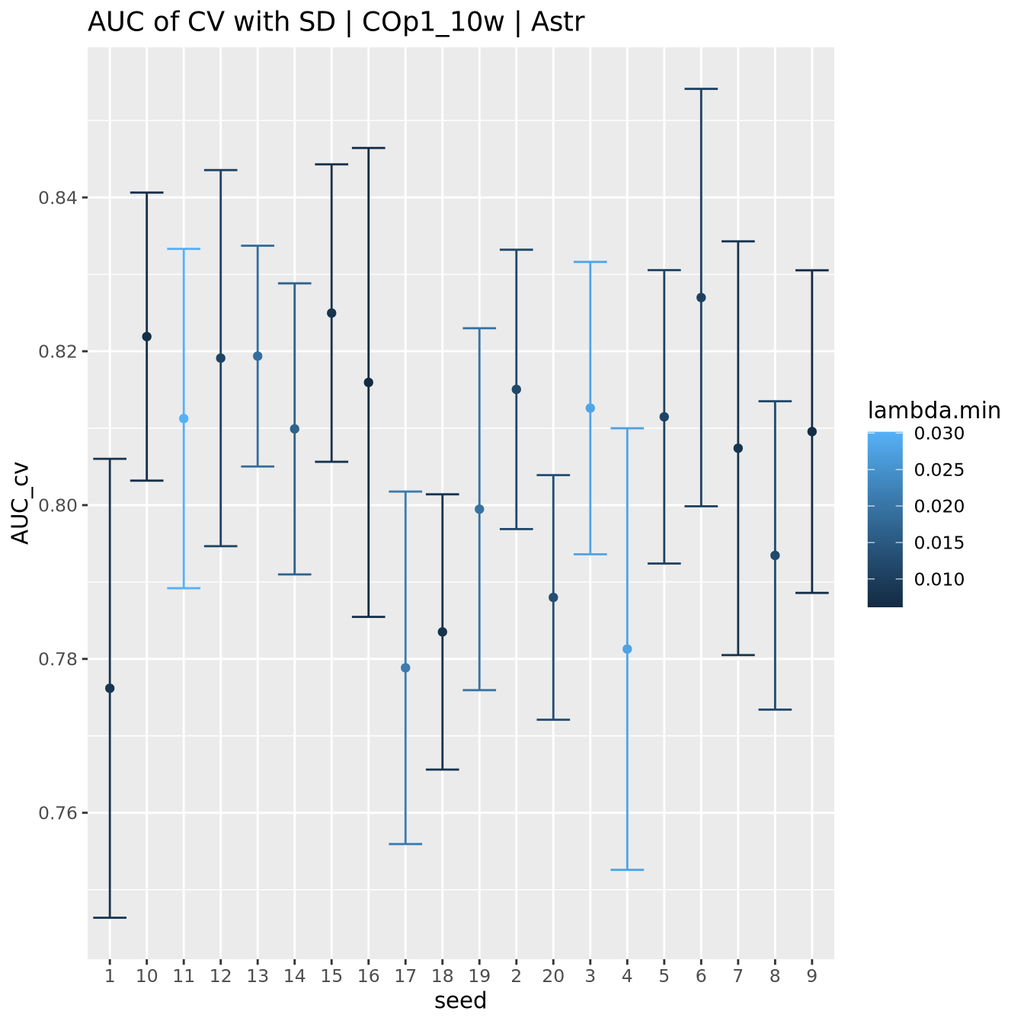

```r
plot_cv_auc_across_seeds(lst_predictions, "AUC of CV with SD | COp1_10w | Astr")
```

**Predict test_organoids - Astrocytes**

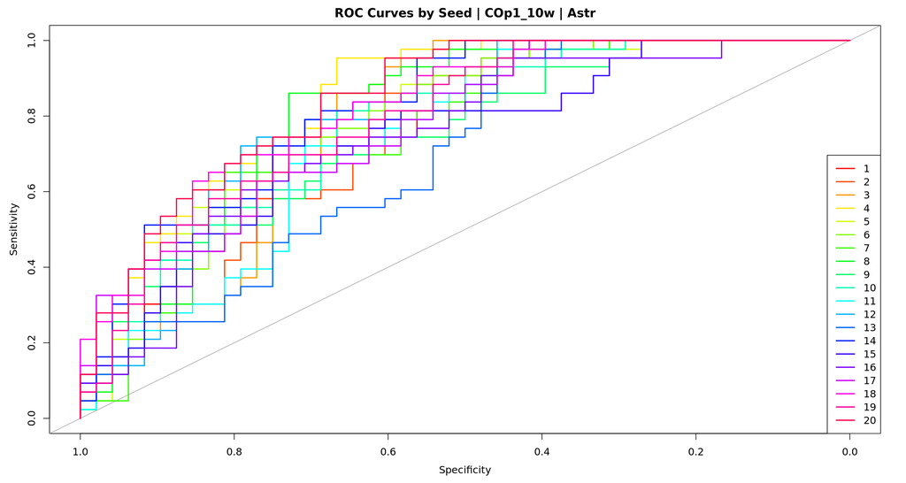

| Seed | AUC | Color |
| --- | --- | --- |
| 1 | 0.766 | #FF0000 |
| 2 | 0.746 | #FF4D00 |
| 3 | 0.774 | #FF9900 |
| 4 | 0.841 | #FFE500 |
| 5 | 0.795 | #CCFF00 |
| 6 | 0.779 | #80FF00 |
| 7 | 0.762 | #33FF00 |
| 8 | 0.802 | #00FF19 |
| 9 | 0.746 | #00FF66 |
| 10 | 0.771 | #00FFB2 |
| 11 | 0.742 | #00FFFF |
| 12 | 0.785 | #00B3FF |
| 13 | 0.692 | #0066FF |
| 14 | 0.819 | #001AFF |
| 15 | 0.743 | #3300FF |
| 16 | 0.743 | #7F00FF |
| 17 | 0.777 | #CC00FF |
| 18 | 0.822 | #FF00E6 |
| 19 | 0.794 | #FF0099 |
| 20 | 0.844 | #FF004D |

```r
plot_roc_by_seed(lst_predictions, "ROC Curves by Seed | COp1_10w | Astr")
```

**AUC across lambda - Astrocytes**

**Top legend is the number of features with nonzero coefficients**

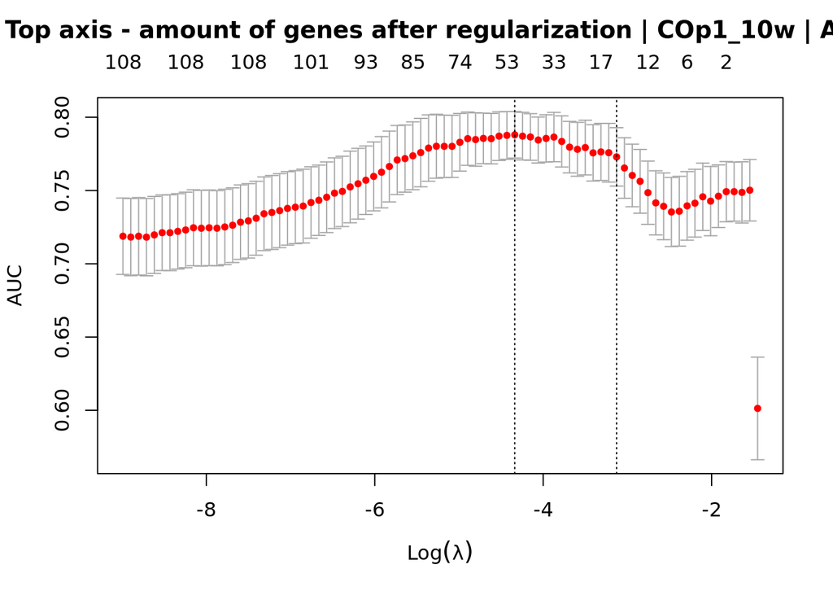

```r
plot_lambda_auc(lst_predictions, "Top axis - amount of genes after regularization | COp1_10w | Astr")
```

**GLMNET - iN**

```r
genenames_model = select_dea_genes(
  file.path(DEA_results_path , "DEA_ICE_vs_wt_COp1_10w_perCT_organoids.csv"), "iN1_ICE_vs_wt"
)
lst_predictions = train_organoid_glmnet(harmonized_seurat_org_iN, genenames_model, n_times)
```

**Error plots - iN**

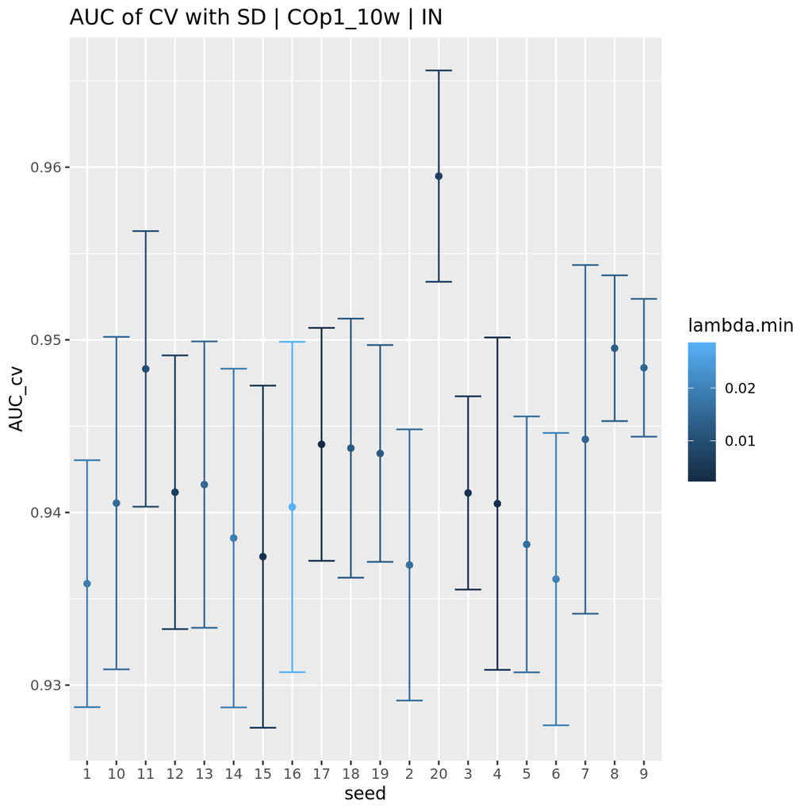

```r
plot_cv_auc_across_seeds(lst_predictions, "AUC of CV with SD | COp1_10w | IN")
```

**Predict test_organoids - iN**

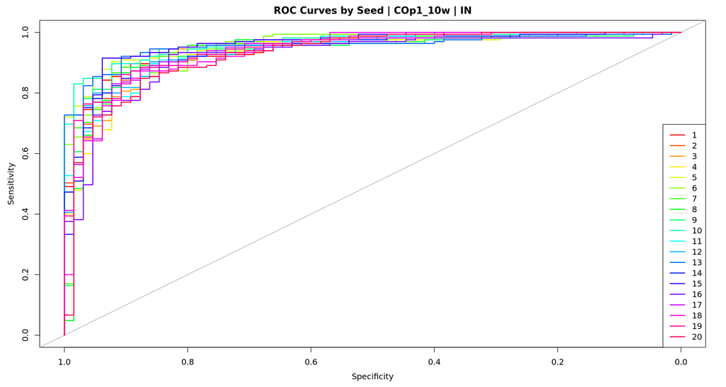

| Seed | AUC | Color |
| --- | --- | --- |
| 1 | 0.948 | #FF0000 |
| 2 | 0.939 | #FF4D00 |
| 3 | 0.942 | #FF9900 |
| 4 | 0.933 | #FFE500 |
| 5 | 0.954 | #CCFF00 |
| 6 | 0.951 | #80FF00 |
| 7 | 0.939 | #33FF00 |
| 8 | 0.943 | #00FF19 |
| 9 | 0.934 | #00FF66 |
| 10 | 0.963 | #00FFB2 |
| 11 | 0.941 | #00FFFF |
| 12 | 0.943 | #00B3FF |
| 13 | 0.955 | #0066FF |
| 14 | 0.939 | #001AFF |
| 15 | 0.957 | #3300FF |
| 16 | 0.921 | #7F00FF |
| 17 | 0.940 | #CC00FF |
| 18 | 0.934 | #FF00E6 |
| 19 | 0.946 | #FF0099 |
| 20 | 0.927 | #FF004D |

```r
plot_roc_by_seed(lst_predictions, "ROC Curves by Seed | COp1_10w | IN")
```

**AUC across lambda - iN**

**Top legend is the number of features with nonzero coefficients**

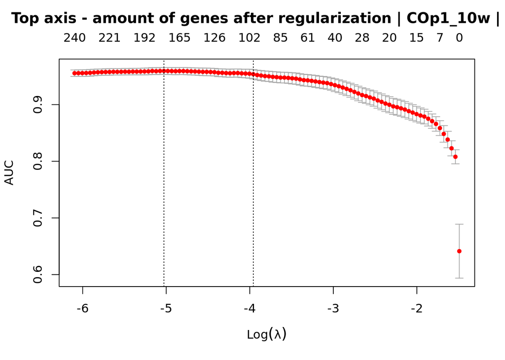

```r
plot_lambda_auc(lst_predictions, "Top axis - amount of genes after regularization | COp1_10w | IN")
```

**coefs - iN**